# Exercise 11.2 (Impute the missing values with known methods)

Use the smoothed time series with gaps from the previous exercise as input. Experiment with different imputation methods discussed in Chapter 5. Visualize the results using the provided plot_production_data function. Discuss the results.

# 1 Load the smoothed time series with gaps from 11.1

```python
import pandas as pd
import matplotlib.pyplot as plt
import seaborn as sns

# Lädt den Produktionsdatensatz aus dem Vorlesungsskript.
url = "https://noxthot.github.io/ws26_industrial_datascience_manuscript/data/assets/act1/selfstudysessions/sss1_production_data.csv"

# Liest die CSV-Datei ein und konvertiert die Spalte "Date" in das Datetime-Format.
df = pd.read_csv(url, parse_dates=["Date"])
df = df.set_index("Date")

# Glättet die Produktionsdaten mit einem gleitenden Median. Analog zur Aufgabe 11.1
df["pieces_median"] = (
    df["pieces_gaps"]
    .rolling(window=7, center=True, min_periods=2)  # Window 7, Reduziert kurzfristige Schwankungen, behält aber langfristigen Trend und saisonale Schwankungen bei.
    .median()
)

# Erhält die ursprünglichen Datenlücken in beiden Ergebnissen.
df.loc[df["pieces_gaps"].isna(),  "pieces_median"] = float("nan")
```

```python
# Plotfunktion aus dem Vorlesungsskript
def plot_production_data(
    df,
    orig_data_column,
    gap_column,
    imp_column=None,
):
    """
    Plots production data with and without gaps using seaborn.
    Parameters:
      df (DataFrame): DataFrame containing the production data.
      orig_data_column (str): Column name for the original data.
      gap_column (str): Column name for the data with gaps.
      imp_column (str): Column name for the imputed data.
    """
    fig, axes = plt.subplots(3 if imp_column else 2, 1, figsize=(12, 10))

    # Original data
    sns.lineplot(x=df.index, y=df[orig_data_column], ax=axes[0], color="grey", label="Original")
    axes[0].set_title("Original Data")
    axes[0].set_ylabel("pieces")

    # With gaps
    sns.lineplot(x=df.index, y=df[gap_column], ax=axes[1], color="black", label="With Gaps")
    axes[1].set_title("Data with Gaps")
    axes[1].set_ylabel("pieces")

    if imp_column is not None:
        dff = df[[gap_column, imp_column]].copy()
        dff.loc[~df[gap_column].isna(), imp_column] = None
        sns.lineplot(x=dff.index, y=dff[imp_column], ax=axes[2], color="blue", label="Imputed")
        axes[2].set_title("Imputed Data")
        axes[2].set_ylabel("pieces")

    plt.tight_layout()
    plt.show()
```

# 2 Imputation with forward fill imputation

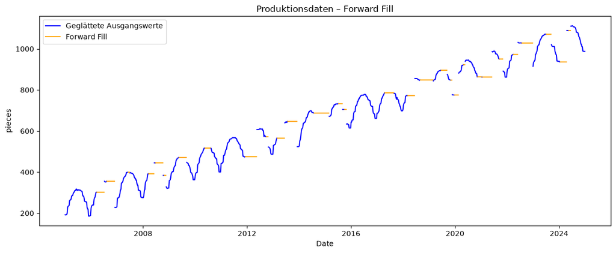

```python
# Forwardfill: Füllt die Lücken in den geglätteten Produktionsdaten mit dem letzten bekannten Wert auf.
df.loc[:, "pieces_ffill"] = df["pieces_median"].ffill()     # .ffill() füllt die NaN-Werte mit dem letzten bekannten Wert auf.


# Ausgabe der Plots
fig, ax = plt.subplots(figsize=(12, 5))

# Geglättete Ausgangswerte mit unterbrochenen Datenlücken.
ax.plot(
    df.index,
    df["pieces_median"],
    color="blue",
    label="Geglättete Ausgangswerte"
)

# Zeigt nur die durch Forward Fill ergänzten Werte.
filled_values = df["pieces_ffill"].where(
    df["pieces_median"].isna()
)

ax.plot(
    df.index,
    filled_values,
    color="orange",
    label="Forward Fill"
)

ax.set_title("Produktionsdaten – Forward Fill")
ax.set_xlabel("Date")
ax.set_ylabel("pieces")
ax.legend()

plt.tight_layout()
plt.show()
```

# 2 Imputation with backward fill imputation

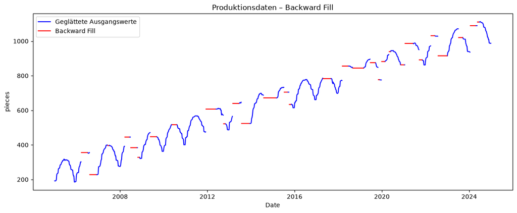

```python
# Backwardfill: Füllt die Lücken in den geglätteten Produktionsdaten mit dem nächsten bekannten Wert auf.
df.loc[:, "pieces_bfill"] = df["pieces_median"].bfill()     # .bfill() füllt die NaN-Werte mit dem nächsten bekannten Wert auf.


# Ausgabe der Plots
fig, ax = plt.subplots(figsize=(12, 5))

# Geglättete Ausgangswerte mit unterbrochenen Datenlücken.
ax.plot(
    df.index,
    df["pieces_median"],
    color="blue",
    label="Geglättete Ausgangswerte"
)

# Zeigt nur die durch Backward Fill ergänzten Werte.
filled_values = df["pieces_bfill"].where(
    df["pieces_median"].isna()
)

ax.plot(
    df.index,
    filled_values,
    color="red",
    label="Backward Fill"
)

ax.set_title("Produktionsdaten – Backward Fill")
ax.set_xlabel("Date")
ax.set_ylabel("pieces")
ax.legend()

plt.tight_layout()
plt.show()
```

# 2 Imputation with linear interpolation

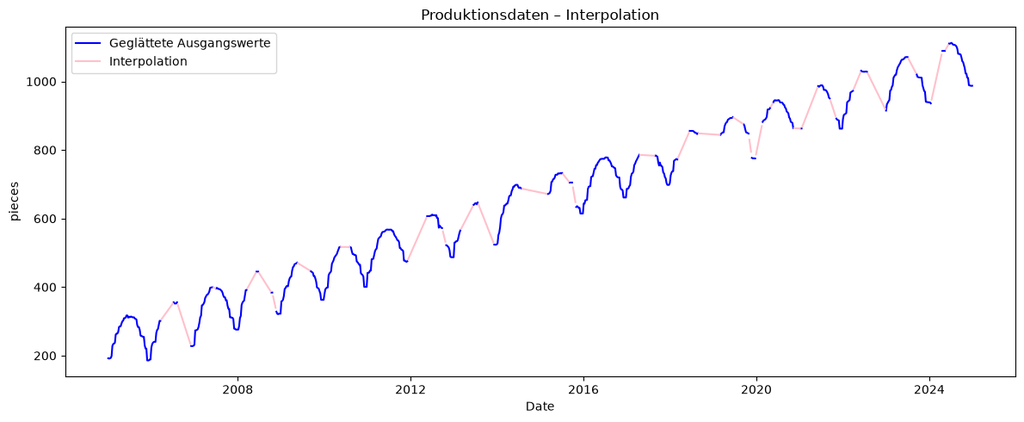

```python
# Linear Interpolation: Füllt die Lücken in den geglätteten Produktionsdaten mit linear interpolierten Werten auf.
df.loc[:, "pieces_lin_interpolated"] = df["pieces_median"].interpolate()     # .interpolate() füllt die NaN-Werte mit linear interpolierten Werten auf.


# Ausgabe der Plots
fig, ax = plt.subplots(figsize=(12, 5))

# Geglättete Ausgangswerte mit unterbrochenen Datenlücken.
ax.plot(
    df.index,
    df["pieces_median"],
    color="blue",
    label="Geglättete Ausgangswerte"
)

# Zeigt nur die durch Interpolation ergänzten Werte.
filled_values = df["pieces_lin_interpolated"].where(
    df["pieces_median"].isna()
)

ax.plot(
    df.index,
    filled_values,
    color="pink",
    label="Interpolation"
)

ax.set_title("Produktionsdaten – Interpolation")
ax.set_xlabel("Date")
ax.set_ylabel("pieces")
ax.legend()

plt.tight_layout()
plt.show()
```

# 2 Imputation with polynomial interpolation

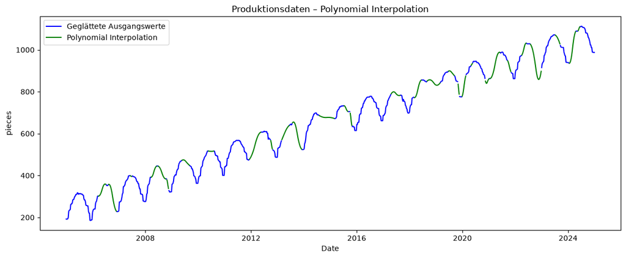

```python
# Polynomial Interpolation: Füllt die Lücken in den geglätteten Produktionsdaten mit polynomial interpolierten Werten auf.
df.loc[:, "pieces_pol_interpolated"] = df["pieces_median"].interpolate(method="polynomial", order=2)     # .interpolate() füllt die NaN-Werte mit polynomial interpolierten Werten auf.


# Ausgabe der Plots
fig, ax = plt.subplots(figsize=(12, 5))

# Geglättete Ausgangswerte mit unterbrochenen Datenlücken.
ax.plot(
    df.index,
    df["pieces_median"],
    color="blue",
    label="Geglättete Ausgangswerte"
)

# Zeigt nur die durch Polynomial Interpolation ergänzten Werte.
filled_values = df["pieces_pol_interpolated"].where(
    df["pieces_median"].isna()
)

ax.plot(
    df.index,
    filled_values,
    color="green",
    label="Polynomial Interpolation"
)

ax.set_title("Produktionsdaten – Polynomial Interpolation")
ax.set_xlabel("Date")
ax.set_ylabel("pieces")
ax.legend()

plt.tight_layout()
plt.show()
```

# 2 Imputation with spline interpolation

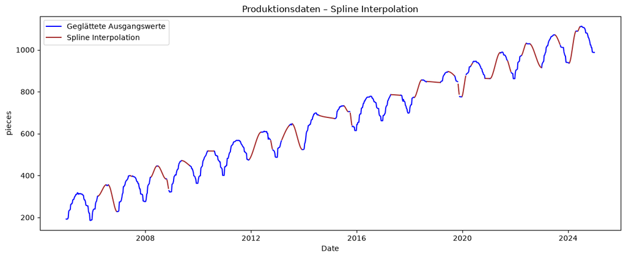

```python
# Spline Interpolation: Füllt die Lücken in den geglätteten Produktionsdaten mit spline interpolierten Werten auf.
df.loc[:, "pieces_spl_interpolated"] = df["pieces_median"].interpolate(method="pchip")     # .interpolate() füllt die NaN-Werte mit pchip interpolierten Werten auf.


# Ausgabe der Plots
fig, ax = plt.subplots(figsize=(12, 5))

# Geglättete Ausgangswerte mit unterbrochenen Datenlücken.
ax.plot(
    df.index,
    df["pieces_median"],
    color="blue",
    label="Geglättete Ausgangswerte"
)

# Zeigt nur die durch Spline Interpolation ergänzten Werte.
filled_values = df["pieces_spl_interpolated"].where(
    df["pieces_median"].isna()
)

ax.plot(
    df.index,
    filled_values,
    color="brown",
    label="Spline Interpolation"
)

ax.set_title("Produktionsdaten – Spline Interpolation")
ax.set_xlabel("Date")
ax.set_ylabel("pieces")
ax.legend()

plt.tight_layout()
plt.show()
```

# 3 Vergleich aller Auffüllmethoden

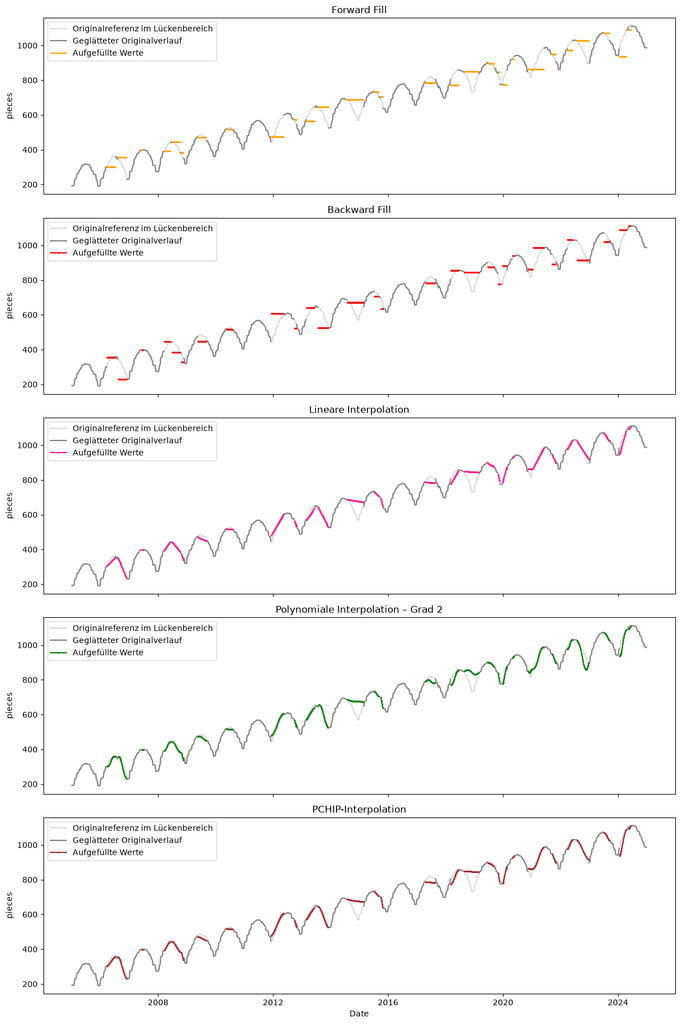

```python
# Glättet die vollständige Originalreihe als Referenz.
original_smoothed = (
    df["pieces"]
    .rolling(window=7, center=True, min_periods=2)
    .median()
)

# Markiert die Lücken der geglätteten Ausgangsreihe.
gaps = df["pieces_median"].isna()

fig, axes = plt.subplots(
    5, 1, figsize=(12, 18), sharex=True, sharey=True
)

columns = [
    "pieces_ffill",
    "pieces_bfill",
    "pieces_lin_interpolated",
    "pieces_pol_interpolated",
    "pieces_spl_interpolated"
]

titles = [
    "Forward Fill",
    "Backward Fill",
    "Lineare Interpolation",
    "Polynomiale Interpolation – Grad 2",
    "PCHIP-Interpolation"
]

colors = ["orange", "red", "deeppink", "green", "brown"]

for ax, column, title, color in zip(axes, columns, titles, colors):

    # Vollständige Referenz zunächst blass zeichnen.
    ax.plot(
        df.index,
        original_smoothed,
        color="grey",
        alpha=0.3,
        label="Originalreferenz im Lückenbereich"
    )

    # Referenz außerhalb der Lücken kräftiger darstellen.
    ax.plot(
        df.index,
        original_smoothed.where(~gaps),
        color="grey",
        label="Geglätteter Originalverlauf"
    )

    # Aufgefüllte Werte farbig darüberzeichnen.
    ax.plot(
        df.index,
        df[column].where(gaps),
        color=color,
        marker=".",
        markersize=2,
        label="Aufgefüllte Werte"
    )

    ax.set_title(title)
    ax.set_ylabel("pieces")
    ax.legend(loc="upper left")

axes[-1].set_xlabel("Date")
plt.tight_layout()
plt.show()
```

```python
print("Spalte vorhanden:", "pieces_pol_interpolated" in df.columns)
```

```
Spalte vorhanden: True
```

# 4 Diskussion der Ergebnisse

```
Forward Fill
```

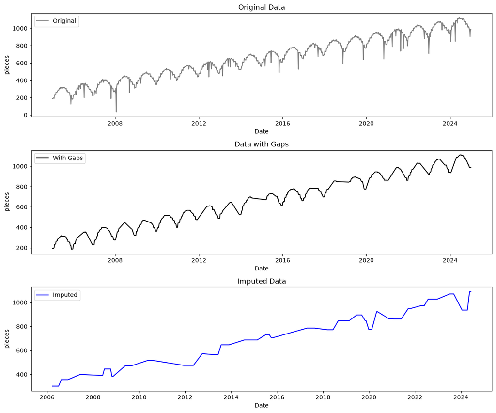

```
Backward Fill
```

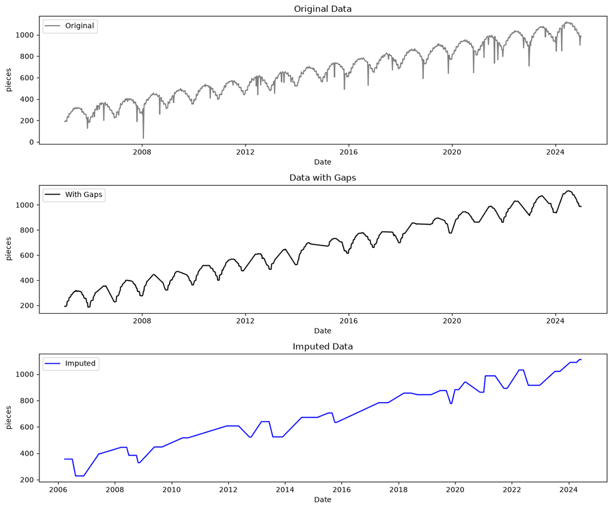

```
Lineare Interpolation
```

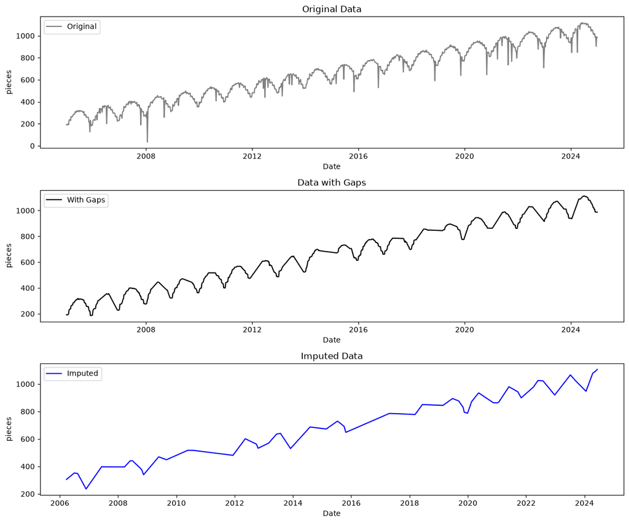

```
Polynomiale Interpolation – Grad 2
```

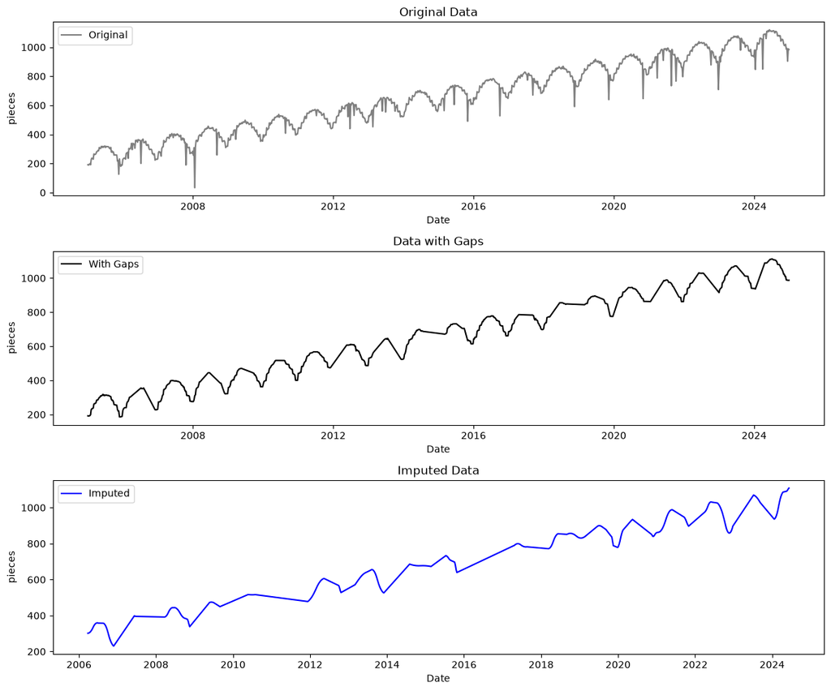

```
PCHIP-Interpolation
```

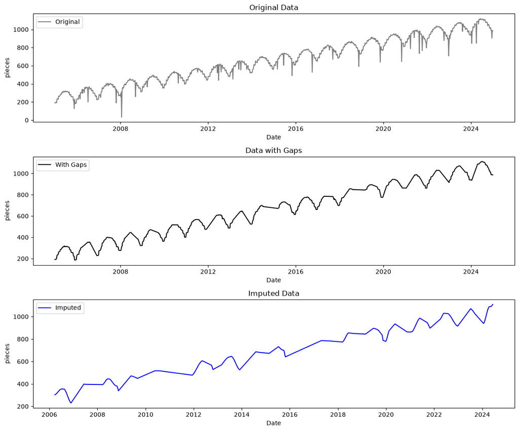

```python
methods = [
    ("pieces_ffill", "Forward Fill"),
    ("pieces_bfill", "Backward Fill"),
    ("pieces_lin_interpolated", "Lineare Interpolation"),
    ("pieces_pol_interpolated", "Polynomiale Interpolation – Grad 2"),
    ("pieces_spl_interpolated", "PCHIP-Interpolation")
]

for column, title in methods:
    print(title)

    plot_production_data(
        df,
        orig_data_column="pieces",
        gap_column="pieces_median",
        imp_column=column
    )
```

## Forward Fill

Füllt die Lücke mit dem letzten verfügbaren Wert auf.

## Backward Fill

Füllt die Lücke mit dem nächsten verfügbaren Wert auf.

## Lineare Interpolation

Verbindet die Randwerte geradlinig. Gekrümmte Verläufe sowie Hoch- und Tiefpunkte innerhalb einer Lücke werden nicht nachgebildet.

## Polynomiale Interpolation

Erzeugt gekrümmte Übergänge, kann aber insbesondere bei längeren Lücken vom Referenzverlauf abweichen.

## Spline-Interpolation (pchip)

Erzeugt formtreue Übergänge zwischen den bekannten Werten und vermeidet Überschwinger. Fehlende saisonale Hoch- und Tiefpunkte werden dadurch jedoch nicht automatisch rekonstruiert.

## Beurteilung

Für die vorliegende Reihe erscheinen interpolierende Verfahren geeigneter als Forward Fill und Backward Fill, weil sie Übergänge zwischen den bekannten Werten berücksichtigen. Die polynomiale Variante liefert im Plot an vielen Stellen einen plausiblen gekrümmten Verlauf. Eine verlässliche Rangfolge der Methoden lässt sich allein aus dem Aussehen jedoch nicht ableiten. Keine der verwendeten Methoden modelliert die saisonale Struktur ausdrücklich.

ipynb exportiert als html mit:

uv run jupyter nbconvert --to html "Tasks/11 Self study - Session 2/Exercise_11.2.ipynb"